# The Language Classification Problem

#### Language processing is a hot topic in virtually all aspects of life, especially in the improvement of better predictive modeling. So this being a priority in proving my analytical skills isn't a surprise. SO LET'S DIVE RIGHT IN!

```python
# Most of the packages we'll use
# Pandas used for loading and cleaning data
# Numpy used for numerical purposes
# Scikit-learn is one of the most used machine learning packages

import pandas as pd
import numpy as np

from sklearn.pipeline import Pipeline
from sklearn.preprocessing import LabelEncoder
from sklearn.linear_model import SGDClassifier

from sklearn.metrics import classification_report as clsr
from sklearn.feature_extraction.text import TfidfVectorizer
from sklearn.cross_validation import train_test_split as tts
from sklearn.cross_validation import cross_val_score
from sklearn.metrics import confusion_matrix, roc_curve
from sklearn.metrics import average_precision_score
from sklearn.utils import shuffle
from sklearn.metrics import roc_curve, auc
```

## Feature Engineering

```python
# Load dataset
lang_sent = pd.read_csv('lang_data.csv')
lang_sent.head()
```

|  | text | language |
| --- | --- | --- |
| 0 | Ship shape and Bristol fashion | English |
| 1 | Know the ropes | English |
| 2 | Graveyard shift | English |
| 3 | Milk of human kindness | English |
| 4 | Touch with a barge-pole - Wouldn't | English |

```python
print(lang_sent.text.shape)
print(lang_sent.language.shape)
```

```
(2839,)
(2839,)
```

```python
# data description (detail)
lang_sent.info()
```

```
<class 'pandas.core.frame.DataFrame'>
RangeIndex: 2839 entries, 0 to 2838
Data columns (total 2 columns):
text        2761 non-null object
language    2839 non-null object
dtypes: object(2)
memory usage: 44.4+ KB
```

```python
lang_sent.describe()
```

|  | text | language |
| --- | --- | --- |
| count | 2761 | 2839 |
| unique | 2752 | 3 |
| top | As fit as a butcher's dog | English |
| freq | 2 | 2077 |

```python
# Drop all NaN instances
new_df = lang_sent.dropna()
print(new_df.text.shape)
print(new_df.language.shape)
new_df.head()
```

```
(2761,)
(2761,)
```

|  | text | language |
| --- | --- | --- |
| 0 | Ship shape and Bristol fashion | English |
| 1 | Know the ropes | English |
| 2 | Graveyard shift | English |
| 3 | Milk of human kindness | English |
| 4 | Touch with a barge-pole - Wouldn't | English |

```python
# Comparing language counts (How often a language occurs)
print('English', new_df[new_df['language'] == 'English'].count())
print('Afrikaans', new_df[new_df['language'] == 'Afrikaans'].count())
print('Nederlands', new_df[new_df['language'] == 'Nederlands'].count())
```

```
('English', text        2055
language    2055
dtype: int64)
('Afrikaans', text        639
language    639
dtype: int64)
('Nederlands', text        67
language    67
dtype: int64)
```

```python
train = new_df['text']
target = new_df['language']
print(train.head())
print(target.head())
```

```
0        Ship shape and Bristol fashion
1                        Know the ropes
2                       Graveyard shift
3                Milk of human kindness
4    Touch with a barge-pole - Wouldn't
Name: text, dtype: object
0    English
1    English
2    English
3    English
4    English
Name: language, dtype: object
```

```python
# Vectorize text features into numerical
dv = TfidfVectorizer()
transformed_data = dv.fit_transform(train).toarray()
transformed_data
```

```
array([[ 0.,  0.,  0., ...,  0.,  0.,  0.],
       [ 0.,  0.,  0., ...,  0.,  0.,  0.],
       [ 0.,  0.,  0., ...,  0.,  0.,  0.],
       ...,
       [ 0.,  0.,  0., ...,  0.,  0.,  0.],
       [ 0.,  0.,  0., ...,  0.,  0.,  0.],
       [ 0.,  0.,  0., ...,  0.,  0.,  0.]])
```

```python
transformed_data.shape
```

```
(2761, 4342)
```

```python
# Convert text labels column to numerical
le = LabelEncoder()
transformed_labels = le.fit_transform(target)
transformed_labels
```

```
array([1, 1, 1, ..., 1, 1, 1])
```

```python
transformed_labels.shape
```

```
(2761,)
```

## Machine Learning

We gonna test our data on five regularly used models. Let's GO!

```python
# Split data for better metrics evaluation
transformed_data, transformed_labels = shuffle(transformed_data, transformed_labels)
from sklearn.cross_validation import train_test_split
transformed_data_train, transformed_data_test, transformed_labels_train, transformed_labels_test = train_test_split(transformed_data, transformed_labels, random_state=0)
```

### Stochastic Gradient Descent Classifier

```python
# Call and fit the classifier
sgd = SGDClassifier()
sgd_model = sgd.fit(transformed_data_train, transformed_labels_train).decision_function(transformed_data_test)
```

```python
# Predict from left out test data
sgd_preds = sgd.predict(transformed_data_test)
```

```python
# Cross Validation using test data
sgd_scores = cross_val_score(sgd, transformed_data_test, transformed_labels_test,  cv = 5, verbose=2)
print('Prediction Accuracy in Percentage form:', sgd_scores.mean() * 100)
```

```
[CV]  ................................................................
[CV] .......................................................  -   0.1s
[CV]  ................................................................
[CV] .......................................................  -   0.1s
[CV]  ................................................................
```

```
[Parallel(n_jobs=1)]: Done   1 out of   1 | elapsed:    0.1s remaining:    0.0s
```

```
[CV] .......................................................  -   0.1s
[CV]  ................................................................
[CV] .......................................................  -   0.1s
[CV]  ................................................................
[CV] .......................................................  -   0.1s
('Prediction Accuracy in Percentage form:', 94.21939820406449)
```

```
[Parallel(n_jobs=1)]: Done   5 out of   5 | elapsed:    0.4s finished
```

```
An interactive shell.

This file is designed to be launched as a PYTHONSTARTUP script.

Confusion matrix, without normalization
[[145  17   1]
 [  1 506   1]
 [  1  10   9]]
Normalized confusion matrix
[[ 0.89  0.1   0.01]
 [ 0.    1.    0.  ]
 [ 0.05  0.5   0.45]]
```

[figure not shown]

[figure not shown]

```python
print(__doc__)

class_names = np.array(['English', 'Afrikaans''Nederlands'])

import itertools
import numpy as np
import matplotlib.pyplot as plt

def plot_confusion_matrix(cm, classes,
                          normalize=False,
                          title='Confusion matrix',
                          cmap=plt.cm.Blues):
    """
    This function prints and plots the confusion matrix.
    Normalization can be applied by setting `normalize=True`.
    """
    plt.imshow(cm, interpolation='nearest', cmap=cmap)
    plt.title(title)
    plt.colorbar()
    tick_marks = np.arange(len(classes))
    plt.xticks(tick_marks, classes, rotation=45)
    plt.yticks(tick_marks, classes)

    if normalize:
        cm = cm.astype('float') / cm.sum(axis=1)[:, np.newaxis]
        print("Normalized confusion matrix")
    else:
        print('Confusion matrix, without normalization')

    print(cm)

    thresh = cm.max() / 2.
    for i, j in itertools.product(range(cm.shape[0]), range(cm.shape[1])):
        plt.text(j, i, cm[i, j],
                 horizontalalignment="center",
                 color="white" if cm[i, j] > thresh else "black")

    plt.tight_layout()
    plt.ylabel('True label')
    plt.xlabel('Predicted label')

# Compute confusion matrix
cnf_matrix = confusion_matrix(transformed_labels_test, sgd_preds)
np.set_printoptions(precision=2)

# Plot non-normalized confusion matrix
plt.figure()
plot_confusion_matrix(cnf_matrix, classes=class_names,
                      title='Confusion matrix, without normalization')

# Plot normalized confusion matrix
plt.figure()
plot_confusion_matrix(cnf_matrix, classes=class_names, normalize=True,
                      title='Normalized confusion matrix')

plt.show()
```

Confusion Matrix is used to assess how well the model fits the data in terms of class confusion or how precise it predicts a class. If the model predicts more confused classes compared to right ones, the model isn't doing well. This indicator will help with the 'class imbalance' issue in terms of choosing the right model.

### Random Forest Classifier

```python
# Import the random forest package
from sklearn.ensemble import RandomForestClassifier

# Create the random forest object which will include all the parameters for the fit
forest = RandomForestClassifier(n_estimators = 100)

# Fit the training data to the Language labels and create the decision trees
forest = forest.fit(transformed_data_train,transformed_labels_train)

# Take the same decision trees and run it on the test data for prediction
forest_preds = forest.predict(transformed_data_test)
```

```python
# Cross Validation again
forest_scores = cross_val_score(forest, transformed_data_test, transformed_labels_test, cv = 5, verbose=2)
print('Prediction Accuracy in Percentage form:', forest_scores.mean() * 100)
```

```
[CV]  ................................................................
[CV] .......................................................  -   1.2s
[CV]  ................................................................
```

```
[Parallel(n_jobs=1)]: Done   1 out of   1 | elapsed:    1.2s remaining:    0.0s
```

```
[CV] .......................................................  -   1.1s
[CV]  ................................................................
[CV] .......................................................  -   1.1s
[CV]  ................................................................
[CV] .......................................................  -   1.1s
[CV]  ................................................................
[CV] .......................................................  -   1.2s
('Prediction Accuracy in Percentage form:', 93.787743527805503)
```

```
[Parallel(n_jobs=1)]: Done   5 out of   5 | elapsed:    5.7s finished
```

```
An interactive shell.

This file is designed to be launched as a PYTHONSTARTUP script.

Confusion matrix, without normalization
[[150  13   0]
 [  1 507   0]
 [  7   8   5]]
Normalized confusion matrix
[[ 0.92  0.08  0.  ]
 [ 0.    1.    0.  ]
 [ 0.35  0.4   0.25]]
```

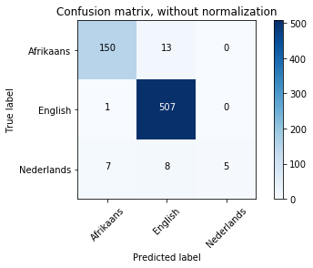

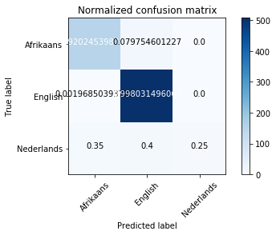

```python
print(__doc__)

class_names = np.array(['Afrikaans', 'English', 'Nederlands'])

import itertools
import numpy as np
import matplotlib.pyplot as plt

def plot_confusion_matrix(cm, classes,
                          normalize=False,
                          title='Confusion matrix',
                          cmap=plt.cm.Blues):
    """
    This function prints and plots the confusion matrix.
    Normalization can be applied by setting `normalize=True`.
    """
    plt.imshow(cm, interpolation='nearest', cmap=cmap)
    plt.title(title)
    plt.colorbar()
    tick_marks = np.arange(len(classes))
    plt.xticks(tick_marks, classes, rotation=45)
    plt.yticks(tick_marks, classes)

    if normalize:
        cm = cm.astype('float') / cm.sum(axis=1)[:, np.newaxis]
        print("Normalized confusion matrix")
    else:
        print('Confusion matrix, without normalization')

    print(cm)

    thresh = cm.max() / 2.
    for i, j in itertools.product(range(cm.shape[0]), range(cm.shape[1])):
        plt.text(j, i, cm[i, j],
                 horizontalalignment="center",
                 color="white" if cm[i, j] > thresh else "black")

    plt.tight_layout()
    plt.ylabel('True label')
    plt.xlabel('Predicted label')

# Compute confusion matrix
cnf_matrix = confusion_matrix(transformed_labels_test, forest_preds)
np.set_printoptions(precision=2)

# Plot non-normalized confusion matrix
plt.figure()
plot_confusion_matrix(cnf_matrix, classes=class_names,
                      title='Confusion matrix, without normalization')

# Plot normalized confusion matrix
plt.figure()
plot_confusion_matrix(cnf_matrix, classes=class_names, normalize=True,
                      title='Normalized confusion matrix')

plt.show()
```

#### The model shows similar sentiments to the previous model. let's try more models! This time a model that deals better with high bias.

### Adaboost Classifier

```python
from sklearn.ensemble import AdaBoostClassifier

# Create the random forest object which will include all the parameters for the fit
adb = AdaBoostClassifier(n_estimators = 100)

# Fit the training data to the Language labels and create the decision trees
adb = adb.fit(transformed_data_train,transformed_labels_train)

# Take the same decision trees and run it on the test data for prediction
adb_preds = adb.predict(transformed_data_test)
```

```python
# Cross Validation again
adb_scores = cross_val_score(adb, transformed_data_test, transformed_labels_test, cv = 5, verbose=2)
print('Prediction Accuracy in Percentage form:', adb_scores.mean() * 100)
```

```
[CV]  ................................................................
[CV] .......................................................  -   2.9s
[CV]  ................................................................
```

```
[Parallel(n_jobs=1)]: Done   1 out of   1 | elapsed:    2.9s remaining:    0.0s
```

```
[CV] .......................................................  -   2.9s
[CV]  ................................................................
[CV] .......................................................  -   2.9s
[CV]  ................................................................
[CV] .......................................................  -   2.9s
[CV]  ................................................................
[CV] .......................................................  -   2.9s
('Prediction Accuracy in Percentage form:', 87.281415743317751)
```

```
[Parallel(n_jobs=1)]: Done   5 out of   5 | elapsed:   14.7s finished
```

```
An interactive shell.

This file is designed to be launched as a PYTHONSTARTUP script.

Confusion matrix, without normalization
[[133  28   2]
 [  3 505   0]
 [  4   6  10]]
Normalized confusion matrix
[[ 0.82  0.17  0.01]
 [ 0.01  0.99  0.  ]
 [ 0.2   0.3   0.5 ]]
```

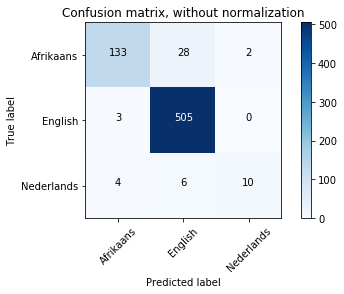

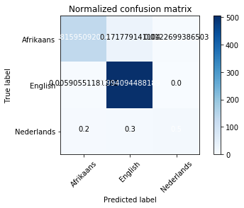

```python
print(__doc__)

class_names = np.array(['Afrikaans', 'English', 'Nederlands'])

import itertools
import numpy as np
import matplotlib.pyplot as plt

def plot_confusion_matrix(cm, classes,
                          normalize=False,
                          title='Confusion matrix',
                          cmap=plt.cm.Blues):
    """
    This function prints and plots the confusion matrix.
    Normalization can be applied by setting `normalize=True`.
    """
    plt.imshow(cm, interpolation='nearest', cmap=cmap)
    plt.title(title)
    plt.colorbar()
    tick_marks = np.arange(len(classes))
    plt.xticks(tick_marks, classes, rotation=45)
    plt.yticks(tick_marks, classes)

    if normalize:
        cm = cm.astype('float') / cm.sum(axis=1)[:, np.newaxis]
        print("Normalized confusion matrix")
    else:
        print('Confusion matrix, without normalization')

    print(cm)

    thresh = cm.max() / 2.
    for i, j in itertools.product(range(cm.shape[0]), range(cm.shape[1])):
        plt.text(j, i, cm[i, j],
                 horizontalalignment="center",
                 color="white" if cm[i, j] > thresh else "black")

    plt.tight_layout()
    plt.ylabel('True label')
    plt.xlabel('Predicted label')

# Compute confusion matrix
cnf_matrix = confusion_matrix(transformed_labels_test, adb_preds)
np.set_printoptions(precision=2)

# Plot non-normalized confusion matrix
plt.figure()
plot_confusion_matrix(cnf_matrix, classes=class_names,
                      title='Confusion matrix, without normalization')

# Plot normalized confusion matrix
plt.figure()
plot_confusion_matrix(cnf_matrix, classes=class_names, normalize=True,
                      title='Normalized confusion matrix')

plt.show()
```

#### Ensembles play a huge role in proper ML model finding procedures, just two should suffice. Plus they can help with reducing bias of the data

### Support Vector Machine Classifier

```python
from sklearn import svm
clf = svm.SVC()
svm = clf.fit(transformed_data_train,transformed_labels_train)
svm_preds = svm.predict(transformed_data_test)
```

```python
# Cross Validation again
svm_scores = cross_val_score(svm, transformed_data_test, transformed_labels_test, cv = 5, verbose=2)
print('Prediction Accuracy in Percentage form:', svm_scores.mean() * 100)
```

```
[CV]  ................................................................
[CV] .......................................................  -   1.2s
[CV]  ................................................................
```

```
[Parallel(n_jobs=1)]: Done   1 out of   1 | elapsed:    1.2s remaining:    0.0s
```

```
[CV] .......................................................  -   1.1s
[CV]  ................................................................
[CV] .......................................................  -   1.1s
[CV]  ................................................................
[CV] .......................................................  -   1.2s
[CV]  ................................................................
[CV] .......................................................  -   1.1s
('Prediction Accuracy in Percentage form:', 73.517828073307783)
```

```
[Parallel(n_jobs=1)]: Done   5 out of   5 | elapsed:    5.7s finished
```

```
An interactive shell.

This file is designed to be launched as a PYTHONSTARTUP script.

Confusion matrix, without normalization
[[  0 163   0]
 [  0 508   0]
 [  0  20   0]]
Normalized confusion matrix
[[ 0.  1.  0.]
 [ 0.  1.  0.]
 [ 0.  1.  0.]]
```

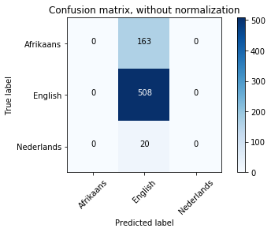

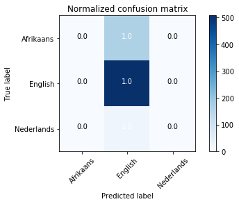

```python
print(__doc__)

class_names = np.array(['Afrikaans', 'English', 'Nederlands'])

import itertools
import numpy as np
import matplotlib.pyplot as plt

def plot_confusion_matrix(cm, classes,
                          normalize=False,
                          title='Confusion matrix',
                          cmap=plt.cm.Blues):
    """
    This function prints and plots the confusion matrix.
    Normalization can be applied by setting `normalize=True`.
    """
    plt.imshow(cm, interpolation='nearest', cmap=cmap)
    plt.title(title)
    plt.colorbar()
    tick_marks = np.arange(len(classes))
    plt.xticks(tick_marks, classes, rotation=45)
    plt.yticks(tick_marks, classes)

    if normalize:
        cm = cm.astype('float') / cm.sum(axis=1)[:, np.newaxis]
        print("Normalized confusion matrix")
    else:
        print('Confusion matrix, without normalization')

    print(cm)

    thresh = cm.max() / 2.
    for i, j in itertools.product(range(cm.shape[0]), range(cm.shape[1])):
        plt.text(j, i, cm[i, j],
                 horizontalalignment="center",
                 color="white" if cm[i, j] > thresh else "black")

    plt.tight_layout()
    plt.ylabel('True label')
    plt.xlabel('Predicted label')

# Compute confusion matrix
cnf_matrix = confusion_matrix(transformed_labels_test, svm_preds)
np.set_printoptions(precision=2)

# Plot non-normalized confusion matrix
plt.figure()
plot_confusion_matrix(cnf_matrix, classes=class_names,
                      title='Confusion matrix, without normalization')

# Plot normalized confusion matrix
plt.figure()
plot_confusion_matrix(cnf_matrix, classes=class_names, normalize=True,
                      title='Normalized confusion matrix')

plt.show()
```

#### Since this is a classification challenge, the 'Support Vector Machine' model couldn't be left out of this race. It seems to be performing the least favourable compared to the ones before. This might be because the clustering is siding with the most favourable classes. One more contender, hopefully this one's it.

### Naive Bayes Classifier

```python
from sklearn.naive_bayes import GaussianNB

gnb = GaussianNB()
gnb.fit(transformed_data_train, transformed_labels_train)
gnb_preds = gnb.predict(transformed_data_test)
```

```python
# Cross_validation
gnb_scores = cross_val_score(gnb, transformed_data_test, transformed_labels_test, cv = 5, verbose=2)
print('Prediction Accuracy in Percentage form:', gnb_scores.mean() * 100)
```

```
[CV]  ................................................................
[CV] .......................................................  -   0.1s
[CV]  ................................................................
[CV] .......................................................  -   0.1s
[CV]  ................................................................
```

```
[Parallel(n_jobs=1)]: Done   1 out of   1 | elapsed:    0.1s remaining:    0.0s
```

```
[CV] .......................................................  -   0.1s
[CV]  ................................................................
[CV] .......................................................  -   0.1s
[CV]  ................................................................
[CV] .......................................................  -   0.1s
('Prediction Accuracy in Percentage form:', 82.929160321377921)
```

```
[Parallel(n_jobs=1)]: Done   5 out of   5 | elapsed:    0.4s finished
```

```
An interactive shell.

This file is designed to be launched as a PYTHONSTARTUP script.

Confusion matrix, without normalization
[[159   2   2]
 [ 16 445  47]
 [  8   0  12]]
Normalized confusion matrix
[[ 0.98  0.01  0.01]
 [ 0.03  0.88  0.09]
 [ 0.4   0.    0.6 ]]
```

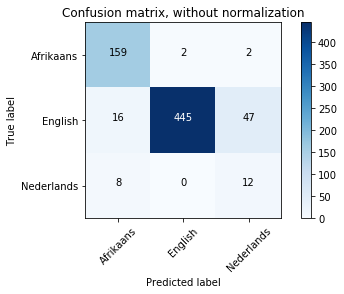

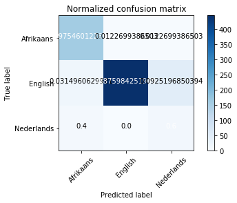

```python
print(__doc__)

class_names = np.array(['Afrikaans', 'English', 'Nederlands'])

import itertools
import numpy as np
import matplotlib.pyplot as plt

def plot_confusion_matrix(cm, classes,
                          normalize=False,
                          title='Confusion matrix',
                          cmap=plt.cm.Blues):
    """
    This function prints and plots the confusion matrix.
    Normalization can be applied by setting `normalize=True`.
    """
    plt.imshow(cm, interpolation='nearest', cmap=cmap)
    plt.title(title)
    plt.colorbar()
    tick_marks = np.arange(len(classes))
    plt.xticks(tick_marks, classes, rotation=45)
    plt.yticks(tick_marks, classes)

    if normalize:
        cm = cm.astype('float') / cm.sum(axis=1)[:, np.newaxis]
        print("Normalized confusion matrix")
    else:
        print('Confusion matrix, without normalization')

    print(cm)

    thresh = cm.max() / 2.
    for i, j in itertools.product(range(cm.shape[0]), range(cm.shape[1])):
        plt.text(j, i, cm[i, j],
                 horizontalalignment="center",
                 color="white" if cm[i, j] > thresh else "black")

    plt.tight_layout()
    plt.ylabel('True label')
    plt.xlabel('Predicted label')

# Compute confusion matrix
cnf_matrix = confusion_matrix(transformed_labels_test, gnb_preds)
np.set_printoptions(precision=2)

# Plot non-normalized confusion matrix
plt.figure()
plot_confusion_matrix(cnf_matrix, classes=class_names,
                      title='Confusion matrix, without normalization')

# Plot normalized confusion matrix
plt.figure()
plot_confusion_matrix(cnf_matrix, classes=class_names, normalize=True,
                      title='Normalized confusion matrix')

plt.show()
```

### It Seems that because of 'class imbalance' of the data, better feature engineering of the data or model finding could and should be implemented; For instance, decomposing the larger class into smaller number of other classes could reduce the level of imbalance. Another process could be to over-sample or under-sample; best choose your flavour right.

Data always has its predicaments in terms of its diversity. At best, models with targets that aren't so classification-driven are more simplified with regression models. Basically regression analysis is the relationship between dependent and independent variables in a dataset (how much does the dependent feature change when an independent variable changes, while other, if more, independent features stay fixed). If this data was simpler and easier to interpret, regression models would play a significant role in terms of predictive modeling.

Another predictive capability in such contexts would be deep learning. Although this type of modeling is more complex then the above tested models, it's accuracy and precision will blow your mind away. It's capabilities lean more towards unsupervised learning. Meaning it best performs at its optimum with data that's not feature/variable targeted. 'Independence' is more its game, it thrives off it. Deep Learning works more like a brain, the more data and experience you feed it, the better it gets. So if your dealing with data that's heavily targeted and dependent, the above models are a good start, but if your looking to solve more extreme and non-dependent data, 'Deep Learning' is your saviour.